# ERGM_EGO_ELSOC

# 18 Modelos sustantivos con `ergm.ego` para ELSOC 2019

1. ¿Qué tan fuerte es la homofilia en la población?
2. ¿cuales son las diferencias entre los grupos de cada parámetro sociodemográfico?

## 18.1 modelo 15 (covariables de interés)

```r
modelo15<-ergm.ego(elsoc_ego~
                  + edges
                  + nodecov("machismo")
                  + nodecov("calentorno")
                  + nodefactor("etnia")
                  + nodefactor("educmpmax")
                  + nodefactor("sexo")
                  + nodefactor("educ")
                  + nodefactor("relig")
                  + nodefactor("ideol")
                  + nodecov("edad"),
                  control=control.ergm.ego(ppopsize="samp",
                                           ppop.wt="sample",
                                           stats.wt="data",
                                           stats.est="survey"),
                  ignore.max.alters=FALSE,
                  boot.R = 10000,
                  ergm = control.ergm(init.method = "MPLE",
                  init.MPLE.samplesize = 5e7,
                  MPLE.constraints.ignore = TRUE,
                  MCMLE.effectiveSize = NULL,
                  MCMC.burnin = 5e4,
                  MCMC.interval = 5e4,
                  MCMC.samplesize = 7500,
                  parallel = 16,
                  SAN.nsteps = 5e7))

summary(modelo15)
```

```
## Call:
## ergm(formula = ergm.formula, constraints = constraints, offset.coef = ergm.offset.coef,
##     target.stats = m, eval.loglik = FALSE, control = control$ergm,
##     ignore.max.alters = FALSE, boot.R = 10000, ergm = ..3)
##
## Monte Carlo Maximum Likelihood Results:
##
##                         Estimate Std. Error MCMC % z value Pr(>|z|)
## offset(netsize.adj)    -7.428927   0.000000      0    -Inf  < 1e-04 ***
## edges                   1.570431   0.546441      0   2.874  0.00405 **
## nodecov.machismo       -0.030550   0.053639      0  -0.570  0.56899
## nodecov.calentorno      0.060830   0.039896      0   1.525  0.12733
## nodefactor.etnia.2      0.200319   0.099739      0   2.008  0.04460 *
## nodefactor.educmpmax.2 -0.098848   0.078681      0  -1.256  0.20900
## nodefactor.educmpmax.3 -0.223436   0.135969      0  -1.643  0.10032
## nodefactor.educmpmax.4 -0.091054   0.136498      0  -0.667  0.50473
## nodefactor.sexo.2      -0.029484   0.046685      0  -0.632  0.52768
## nodefactor.educ.2       0.129730   0.061546      0   2.108  0.03504 *
## nodefactor.educ.3       0.234651   0.088493      0   2.652  0.00801 **
## nodefactor.educ.4       0.586862   0.093181      0   6.298  < 1e-04 ***
## nodefactor.relig.2     -0.059799   0.072063      0  -0.830  0.40664
## nodefactor.relig.3     -0.467806   0.081277      0  -5.756  < 1e-04 ***
## nodefactor.relig.4     -0.213234   0.081665      0  -2.611  0.00903 **
## nodefactor.ideol.2      0.044779   0.107593      0   0.416  0.67727
## nodefactor.ideol.3     -0.570753   0.095026      0  -6.006  < 1e-04 ***
## nodefactor.ideol.4     -0.440346   0.105773      0  -4.163  < 1e-04 ***
## nodefactor.ideol.5      0.034497   0.099591      0   0.346  0.72905
## nodefactor.ideol.6      0.034203   0.082715      0   0.414  0.67923
## nodecov.edad           -0.009215   0.001906      0  -4.835  < 1e-04 ***
## ---
## Signif. codes:  0 '***' 0.001 '**' 0.01 '*' 0.05 '.' 0.1 ' ' 1
##
##
##  The following terms are fixed by offset and are not estimated:
##   offset(netsize.adj)
```

## 18.2 modelo 16 (homofilia todos los alteris)

```r
modelo16<-ergm.ego(elsoc_ego~edges
                  + nodematch("sexo",  diff=TRUE)
                  + nodematch("educ",  diff=TRUE)
                  + nodematch("relig", diff=TRUE)
                  + nodematch("ideol", diff=TRUE)
                  + nodematch("barrio", diff=TRUE)
                  + absdiff("edad"),
                  control=control.ergm.ego(ppopsize="samp",
                                           ppop.wt="sample",
                                           stats.wt="data",
                                           stats.est="survey"),
                  ignore.max.alters=FALSE,
                  boot.R = 10000,
                  ergm = control.ergm(init.method = "MPLE",
                  init.MPLE.samplesize = 5e7,
                  MPLE.constraints.ignore = TRUE,
                  MCMLE.effectiveSize = NULL,
                  MCMC.burnin = 5e4,
                  MCMC.interval = 5e4,
                  MCMC.samplesize = 7500,
                  parallel = 16,
                  SAN.nsteps = 5e7))

#?control.ergm.ego
summary(modelo16)
```

```
## Call:
## ergm(formula = ergm.formula, constraints = constraints, offset.coef = ergm.offset.coef,
##     target.stats = m, eval.loglik = FALSE, control = control$ergm,
##     ignore.max.alters = FALSE, boot.R = 10000, ergm = ..3)
##
## Monte Carlo Maximum Likelihood Results:
##
##                      Estimate Std. Error MCMC % z value Pr(>|z|)
## offset(netsize.adj) -7.428927   0.000000      0    -Inf  < 1e-04 ***
## edges               -0.112787   0.066998      0  -1.683 0.092291 .
## nodematch.sexo.1     0.579326   0.059162      0   9.792  < 1e-04 ***
## nodematch.sexo.2     0.370085   0.046676      0   7.929  < 1e-04 ***
## nodematch.educ.1     0.234483   0.107704      0   2.177 0.029473 *
## nodematch.educ.2     0.463061   0.066669      0   6.946  < 1e-04 ***
## nodematch.educ.3     0.889956   0.099324      0   8.960  < 1e-04 ***
## nodematch.educ.4     1.860290   0.088422      0  21.039  < 1e-04 ***
## nodematch.relig.1    1.103725   0.069142      0  15.963  < 1e-04 ***
## nodematch.relig.2    1.857548   0.092538      0  20.073  < 1e-04 ***
## nodematch.relig.3    0.687087   0.166858      0   4.118  < 1e-04 ***
## nodematch.relig.4    1.379862   0.112378      0  12.279  < 1e-04 ***
## nodematch.ideol.1    1.930456   0.167233      0  11.544  < 1e-04 ***
## nodematch.ideol.2    1.062662   0.295598      0   3.595 0.000324 ***
## nodematch.ideol.3   -0.643037   0.143593      0  -4.478  < 1e-04 ***
## nodematch.ideol.4    0.460188   0.169138      0   2.721 0.006513 **
## nodematch.ideol.5    2.096680   0.133543      0  15.700  < 1e-04 ***
## nodematch.ideol.6    1.101333   0.072209      0  15.252  < 1e-04 ***
## nodematch.barrio.1   0.378082   0.071905      0   5.258  < 1e-04 ***
## nodematch.barrio.2  -0.447405   0.053083      0  -8.428  < 1e-04 ***
## absdiff.edad        -0.029480   0.002411      0 -12.225  < 1e-04 ***
## ---
## Signif. codes:  0 '***' 0.001 '**' 0.01 '*' 0.05 '.' 0.1 ' ' 1
##
##
##  The following terms are fixed by offset and are not estimated:
##   offset(netsize.adj)
```

## 18.3 modelo 17 (todos los parámetros)

```r
modelo17 <- ergm.ego(elsoc_ego ~
                  + nodecov("calentorno")
                  + nodecov("machismo")
                  + nodefactor("etnia")
                  + nodefactor("educmpmax")
                  + nodefactor("sexo")
                  + nodefactor("educ")
                  + nodefactor("relig")
                  + nodefactor("ideol")
                  + nodecov("edad")
                  + nodematch("sexo",  diff=TRUE)
                  + nodematch("educ",  diff=TRUE)
                  + nodematch("relig", diff=TRUE)
                  + nodematch("ideol", diff=TRUE)
                  + nodematch("barrio", diff=TRUE)
                  + absdiff("edad"),
                  control=control.ergm.ego(ppopsize="samp",
                                           ppop.wt="sample",
                                           stats.wt="data",
                                           stats.est="survey"),
                  ignore.max.alters=FALSE,
                  boot.R = 10000,
                  ergm = control.ergm(init.method = "MPLE",
                  init.MPLE.samplesize = 5e7,
                  MPLE.constraints.ignore = TRUE,
                  MCMLE.effectiveSize = NULL,
                  MCMC.burnin = 5e4,
                  MCMC.interval = 5e4,
                  MCMC.samplesize = 7500,
                  parallel = 16,
                  SAN.nsteps = 5e7))

summary(modelo17)
```

```
## Call:
## ergm(formula = ergm.formula, constraints = constraints, offset.coef = ergm.offset.coef,
##     target.stats = m, eval.loglik = FALSE, control = control$ergm,
##     ignore.max.alters = FALSE, boot.R = 10000, ergm = ..3)
##
## Monte Carlo Maximum Likelihood Results:
##
##                         Estimate Std. Error MCMC % z value Pr(>|z|)
## offset(netsize.adj)    -7.428927   0.000000      0    -Inf  < 1e-04 ***
## nodecov.calentorno      0.062390   0.045301      0   1.377 0.168437
## nodecov.machismo       -0.054258   0.056387      0  -0.962 0.335927
## nodefactor.etnia.2      0.114311   0.087296      0   1.309 0.190376
## nodefactor.educmpmax.2  0.071382   0.083137      0   0.859 0.390556
## nodefactor.educmpmax.3  0.042805   0.131766      0   0.325 0.745289
## nodefactor.educmpmax.4  0.190350   0.137290      0   1.386 0.165601
## nodefactor.sexo.2       0.259754   0.649709      0   0.400 0.689304
## nodefactor.educ.2       0.270558   0.084544      0   3.200 0.001373 **
## nodefactor.educ.3       0.317154   0.101989      0   3.110 0.001873 **
## nodefactor.educ.4       0.126026   0.106770      0   1.180 0.237862
## nodefactor.relig.2     -0.197011   0.109559      0  -1.798 0.072142 .
## nodefactor.relig.3      0.317986   0.127908      0   2.486 0.012917 *
## nodefactor.relig.4      0.283758   0.115688      0   2.453 0.014175 *
## nodefactor.ideol.2      0.154993   0.114646      0   1.352 0.176397
## nodefactor.ideol.3     -0.300675   0.126976      0  -2.368 0.017887 *
## nodefactor.ideol.4     -0.212672   0.123436      0  -1.723 0.084900 .
## nodefactor.ideol.5     -0.129637   0.126818      0  -1.022 0.306673
## nodefactor.ideol.6     -0.159943   0.116003      0  -1.379 0.167963
## nodecov.edad           -0.008079   0.002248      0  -3.594 0.000325 ***
## nodematch.sexo.1        0.880571   0.662628      0   1.329 0.183879
## nodematch.sexo.2        0.034752   0.671911      0   0.052 0.958751
## nodematch.educ.1        0.840531   0.128573      0   6.537  < 1e-04 ***
## nodematch.educ.2        0.370211   0.098233      0   3.769 0.000164 ***
## nodematch.educ.3        0.779130   0.127390      0   6.116  < 1e-04 ***
## nodematch.educ.4        1.483399   0.128277      0  11.564  < 1e-04 ***
## nodematch.relig.1       1.365578   0.128443      0  10.632  < 1e-04 ***
## nodematch.relig.2       2.364021   0.145091      0  16.293  < 1e-04 ***
## nodematch.relig.3       0.207193   0.228252      0   0.908 0.364018
## nodematch.relig.4       1.071233   0.156672      0   6.837  < 1e-04 ***
## nodematch.ideol.1       1.668106   0.234382      0   7.117  < 1e-04 ***
## nodematch.ideol.2       0.734326   0.338906      0   2.167 0.030253 *
## nodematch.ideol.3      -0.325886   0.184307      0  -1.768 0.077032 .
## nodematch.ideol.4       0.608328   0.208230      0   2.921 0.003484 **
## nodematch.ideol.5       1.639447   0.181956      0   9.010  < 1e-04 ***
## nodematch.ideol.6       1.178124   0.125417      0   9.394  < 1e-04 ***
## nodematch.barrio.1      0.407518   0.072422      0   5.627  < 1e-04 ***
## nodematch.barrio.2     -0.451648   0.054010      0  -8.362  < 1e-04 ***
## absdiff.edad           -0.029681   0.002425      0 -12.238  < 1e-04 ***
## ---
## Signif. codes:  0 '***' 0.001 '**' 0.01 '*' 0.05 '.' 0.1 ' ' 1
##
##
##  The following terms are fixed by offset and are not estimated:
##   offset(netsize.adj)
```

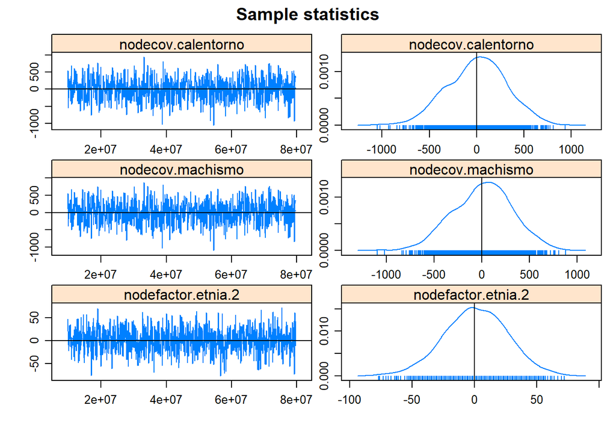

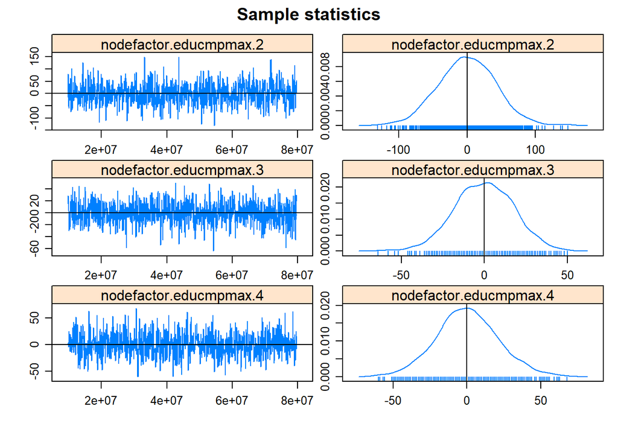

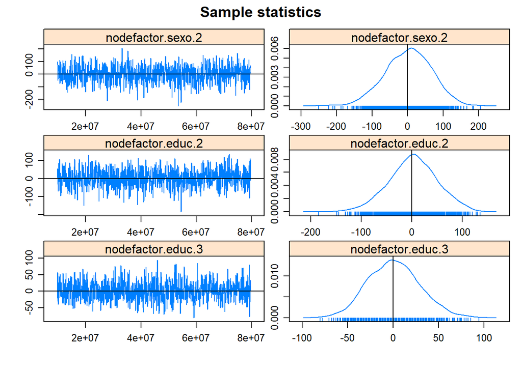

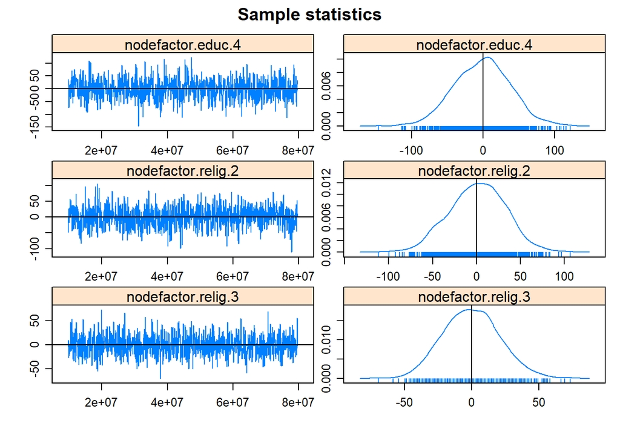

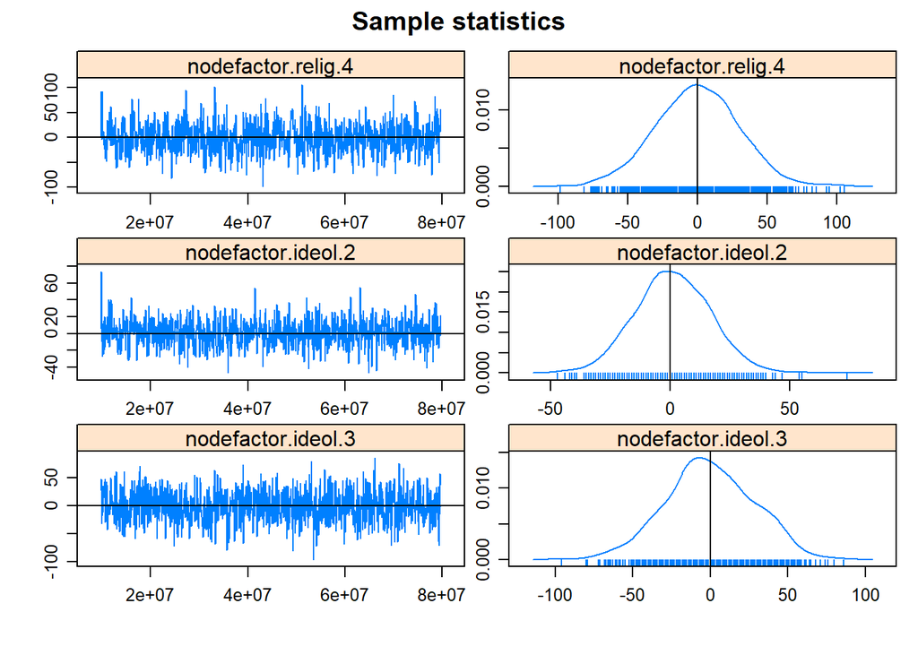

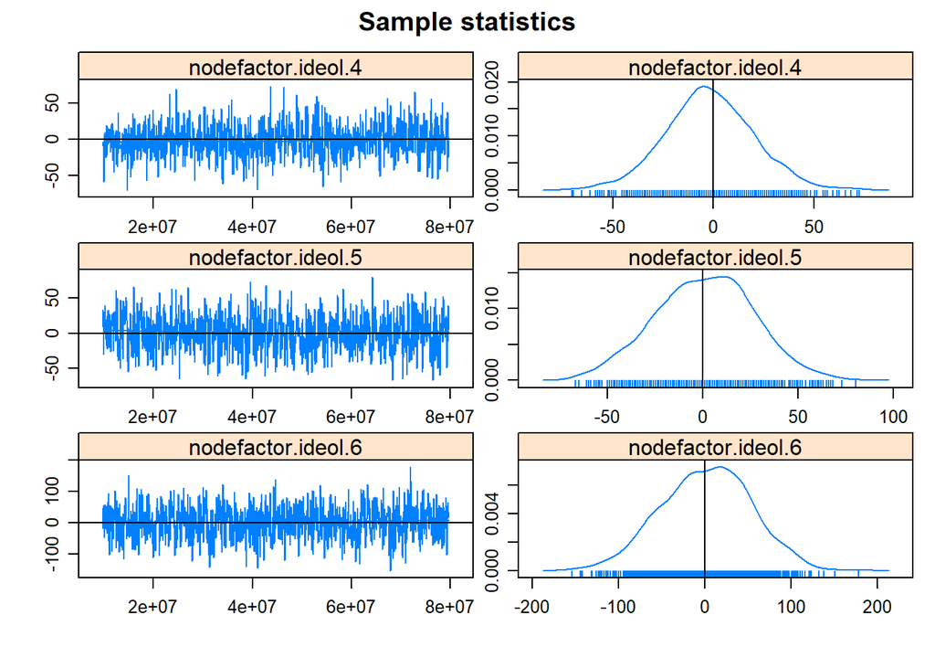

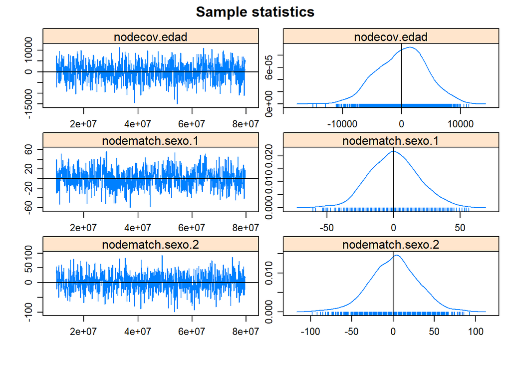

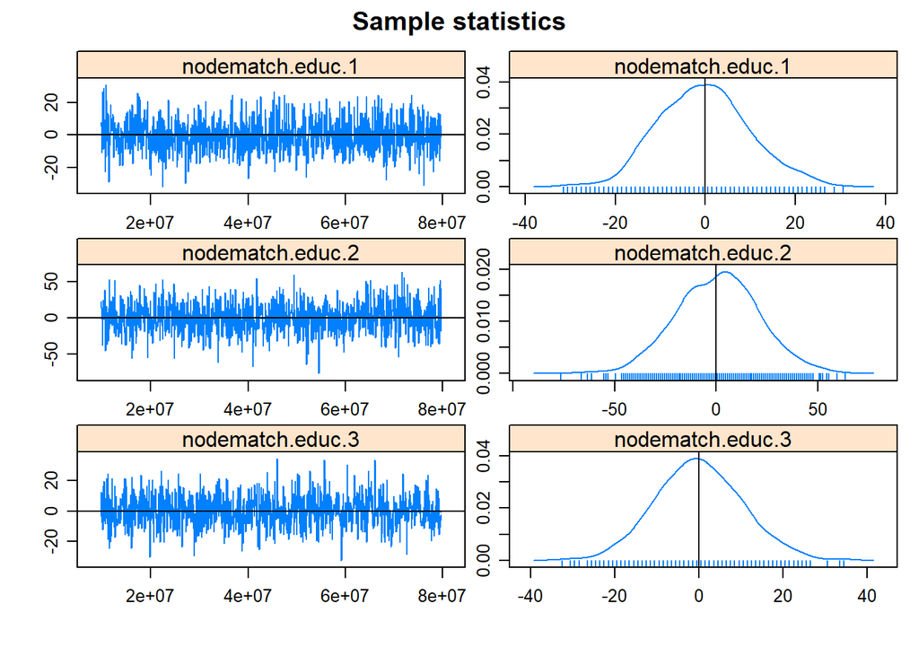

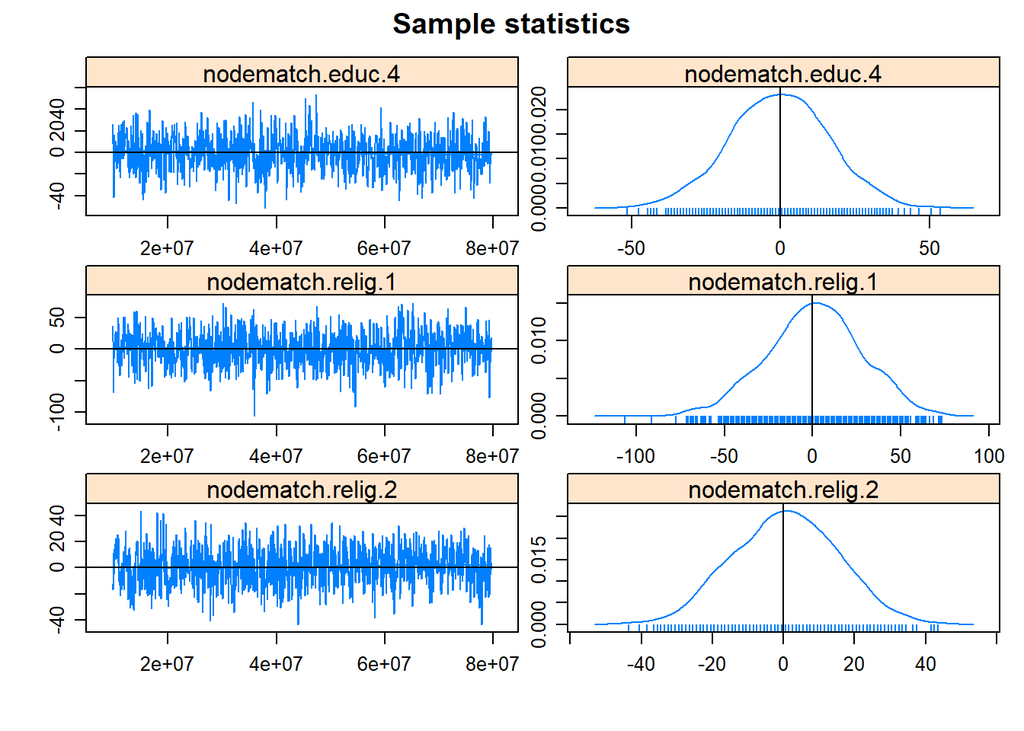

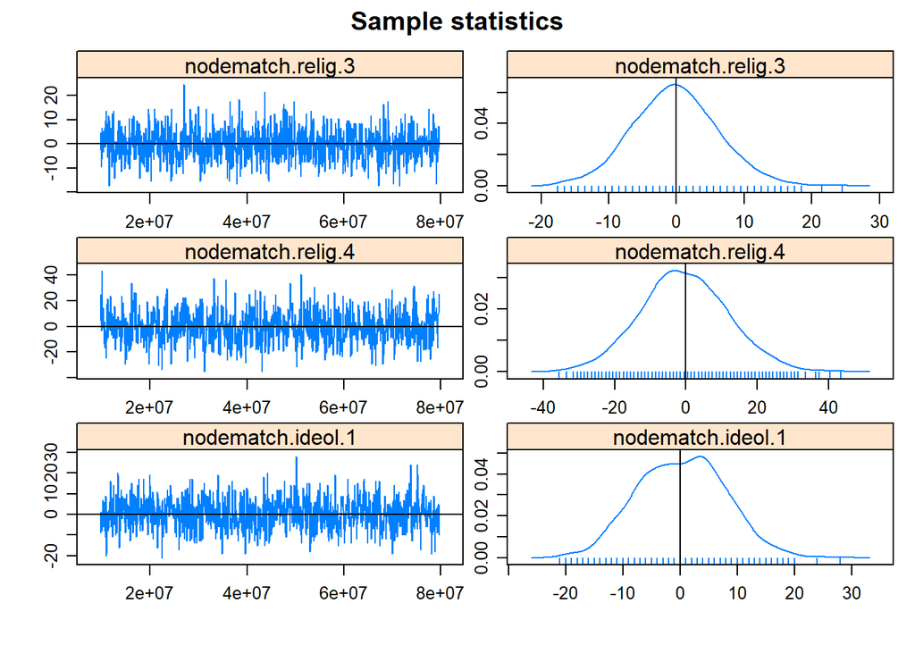

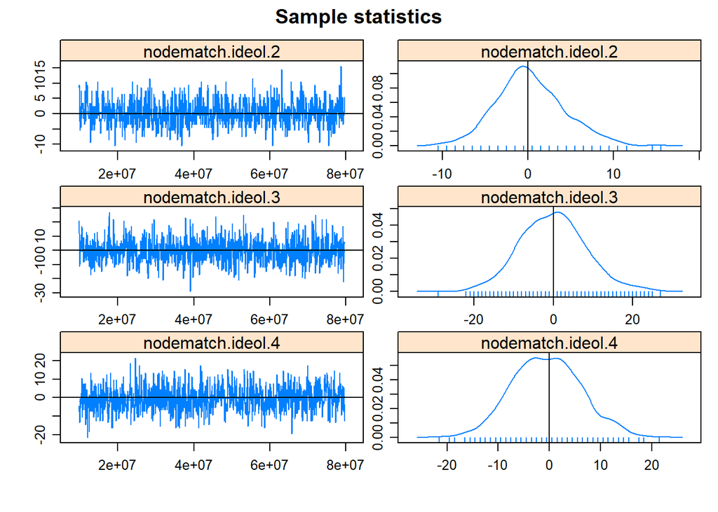

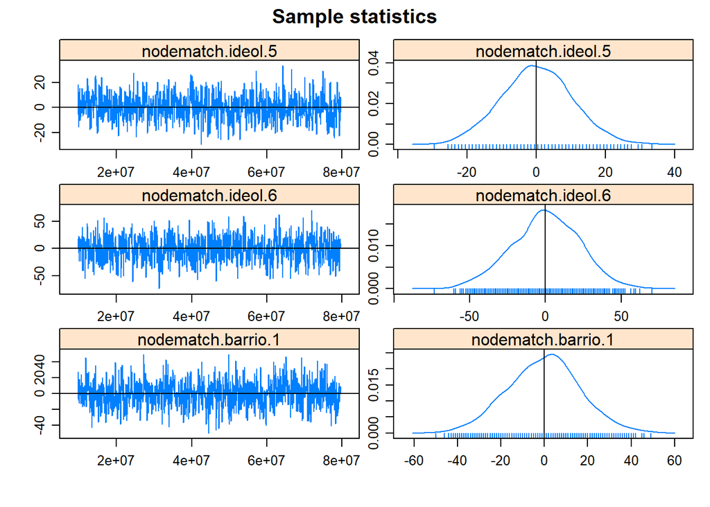

[1 more figures not shown]

[output not shown]

```r
mcmc.diagnostics(modelo17, which ="plots")
```

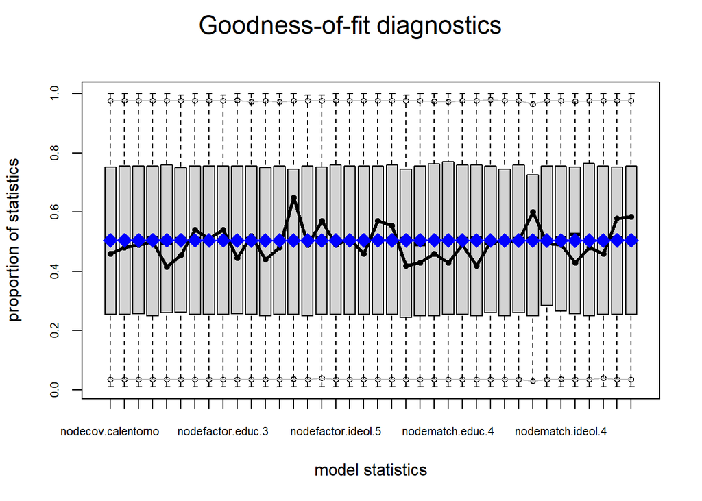

```r
plot(gof(modelo17, GOF="model"))
```

```r
elsoc_ego_nofam[["ego"]]  <-elsoc_ego_nofam[["ego"]]%>%drop_na(edad)
elsoc_ego_nofam[["alter"]]<-elsoc_ego_nofam[["alter"]]%>%drop_na(edad)
elsoc_ego_nofam[["ego"]]  <-elsoc_ego_nofam[["ego"]]%>%drop_na(relig)
elsoc_ego_nofam[["alter"]]<-elsoc_ego_nofam[["alter"]]%>%drop_na(relig)
elsoc_ego_nofam[["ego"]]  <-elsoc_ego_nofam[["ego"]]%>%drop_na(sexo)
elsoc_ego_nofam[["alter"]]<-elsoc_ego_nofam[["alter"]]%>%drop_na(sexo)
elsoc_ego_nofam[["ego"]]  <-elsoc_ego_nofam[["ego"]]%>%drop_na(ideol)
elsoc_ego_nofam[["alter"]]<-elsoc_ego_nofam[["alter"]]%>%drop_na(ideol)
elsoc_ego_nofam[["ego"]]  <-elsoc_ego_nofam[["ego"]]%>%drop_na(educ)
elsoc_ego_nofam[["alter"]]<-elsoc_ego_nofam[["alter"]]%>%drop_na(educ)
elsoc_ego_nofam[["alter"]]<-elsoc_ego_nofam[["alter"]]%>%drop_na(barrio)
elsoc_ego_nofam[["ego"]]$calentorno<-as.numeric(elsoc_ego_nofam[["ego"]]$calentorno)
elsoc_ego_nofam[["ego"]]<-elsoc_ego_nofam[["ego"]]%>%drop_na(calentorno)
elsoc_ego_nofam[["ego"]]$machismo<-as.numeric(elsoc_ego_nofam[["ego"]]$machismo)
elsoc_ego_nofam[["ego"]]<-elsoc_ego_nofam[["ego"]]%>%drop_na(machismo)

#elsoc_ego[["ego"]]$educmpmax<-as.numeric(elsoc_ego[["ego"]]$educmpmax)
elsoc_ego_nofam[["ego"]]<-elsoc_ego_nofam[["ego"]]%>%drop_na(educmpmax)
elsoc_ego_nofam[["ego"]]<-elsoc_ego_nofam[["ego"]]%>%drop_na(etnia)
```

```r
modelo18<-ergm.ego(elsoc_ego_nofam~
                  + edges
                  + nodecov("machismo")
                  + nodecov("calentorno")
                  + nodefactor("etnia")
                  + nodefactor("educmpmax")
                  + nodefactor("sexo")
                  + nodefactor("educ")
                  + nodefactor("relig")
                  + nodefactor("ideol")
                  + nodecov("edad"),
                  control=control.ergm.ego(ppopsize="samp",
                                           ppop.wt="sample",
                                           stats.wt="data",
                                           stats.est="survey"),
                  ignore.max.alters=FALSE,
                  boot.R = 10000,
                  ergm = control.ergm(init.method = "MPLE",
                  init.MPLE.samplesize = 5e7,
                  MPLE.constraints.ignore = TRUE,
                  MCMLE.effectiveSize = NULL,
                  MCMC.burnin = 5e4,
                  MCMC.interval = 5e4,
                  MCMC.samplesize = 7500,
                  parallel = 16,
                  SAN.nsteps = 5e7))

summary(modelo18)
```

```
## Call:
## ergm(formula = ergm.formula, constraints = constraints, offset.coef = ergm.offset.coef,
##     target.stats = m, eval.loglik = FALSE, control = control$ergm,
##     ignore.max.alters = FALSE, boot.R = 10000, ergm = ..3)
##
## Monte Carlo Maximum Likelihood Results:
##
##                         Estimate Std. Error MCMC % z value Pr(>|z|)
## offset(netsize.adj)    -7.428927   0.000000      0    -Inf  < 1e-04 ***
## edges                  -0.140426   0.857080      0  -0.164 0.869855
## nodecov.machismo       -0.042067   0.079603      0  -0.528 0.597183
## nodecov.calentorno      0.063811   0.062235      0   1.025 0.305213
## nodefactor.etnia.2      0.339778   0.123755      0   2.746 0.006040 **
## nodefactor.educmpmax.2 -0.057954   0.108387      0  -0.535 0.592862
## nodefactor.educmpmax.3  0.011306   0.161998      0   0.070 0.944359
## nodefactor.educmpmax.4  0.052788   0.172341      0   0.306 0.759374
## nodefactor.sexo.2      -0.067115   0.074872      0  -0.896 0.370039
## nodefactor.educ.2       0.416700   0.110647      0   3.766 0.000166 ***
## nodefactor.educ.3       0.672515   0.141326      0   4.759  < 1e-04 ***
## nodefactor.educ.4       1.052618   0.143860      0   7.317  < 1e-04 ***
## nodefactor.relig.2     -0.100324   0.110373      0  -0.909 0.363378
## nodefactor.relig.3     -0.396087   0.113239      0  -3.498 0.000469 ***
## nodefactor.relig.4     -0.033982   0.110675      0  -0.307 0.758810
## nodefactor.ideol.2     -0.135122   0.151552      0  -0.892 0.372615
## nodefactor.ideol.3     -0.698223   0.129368      0  -5.397  < 1e-04 ***
## nodefactor.ideol.4     -0.555424   0.152884      0  -3.633 0.000280 ***
## nodefactor.ideol.5      0.114957   0.144816      0   0.794 0.427304
## nodefactor.ideol.6     -0.103043   0.128191      0  -0.804 0.421496
## nodecov.edad           -0.006914   0.003070      0  -2.252 0.024306 *
## ---
## Signif. codes:  0 '***' 0.001 '**' 0.01 '*' 0.05 '.' 0.1 ' ' 1
##
##
##  The following terms are fixed by offset and are not estimated:
##   offset(netsize.adj)
```

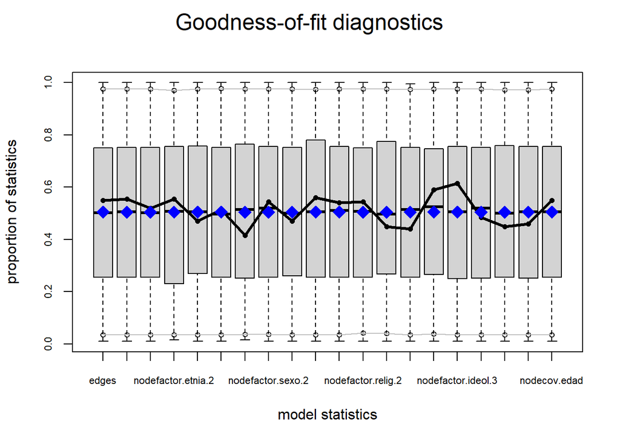

```r
plot(gof(modelo18, GOF="model"))
```

# 19 modelo 19 (alteris no fam homofilia diferencial)

```r
modelo19<-ergm.ego(elsoc_ego_nofam~edges
                  + nodematch("sexo",  diff=TRUE)
                  + nodematch("educ",  diff=TRUE)
                  + nodematch("relig", diff=TRUE)
                  + nodematch("ideol", diff=TRUE)
                  + nodematch("barrio", diff=TRUE)
                  + absdiff("edad"),
                  control=control.ergm.ego(ppopsize="samp",
                                           ppop.wt="sample",
                                           stats.wt="data",
                                           stats.est="survey"),
                  ignore.max.alters=FALSE,
                  boot.R = 10000,
                  ergm = control.ergm(init.method = "MPLE",
                  init.MPLE.samplesize = 5e7,
                  MPLE.constraints.ignore = TRUE,
                  MCMLE.effectiveSize = NULL,
                  MCMC.burnin = 5e4,
                  MCMC.interval = 5e4,
                  MCMC.samplesize = 7500,
                  parallel = 16,
                  SAN.nsteps = 5e7))

#?control.ergm.ego
summary(modelo19)
```

```
## Call:
## ergm(formula = ergm.formula, constraints = constraints, offset.coef = ergm.offset.coef,
##     target.stats = m, eval.loglik = FALSE, control = control$ergm,
##     ignore.max.alters = FALSE, boot.R = 10000, ergm = ..3)
##
## Monte Carlo Maximum Likelihood Results:
##
##                      Estimate Std. Error MCMC % z value Pr(>|z|)
## offset(netsize.adj) -7.428927   0.000000      0    -Inf  < 1e-04 ***
## edges               -1.132152   0.112911      0 -10.027  < 1e-04 ***
## nodematch.sexo.1     1.643342   0.113421      0  14.489  < 1e-04 ***
## nodematch.sexo.2     1.190434   0.092818      0  12.825  < 1e-04 ***
## nodematch.educ.1     0.105395   0.173818      0   0.606  0.54428
## nodematch.educ.2     0.593215   0.096978      0   6.117  < 1e-04 ***
## nodematch.educ.3     1.362035   0.140463      0   9.697  < 1e-04 ***
## nodematch.educ.4     1.875104   0.117886      0  15.906  < 1e-04 ***
## nodematch.relig.1    0.817922   0.083670      0   9.776  < 1e-04 ***
## nodematch.relig.2    1.356549   0.141325      0   9.599  < 1e-04 ***
## nodematch.relig.3    0.256667   0.253114      0   1.014  0.31056
## nodematch.relig.4    1.183282   0.171715      0   6.891  < 1e-04 ***
## nodematch.ideol.1    2.119843   0.230135      0   9.211  < 1e-04 ***
## nodematch.ideol.2    0.384207   0.395268      0   0.972  0.33104
## nodematch.ideol.3   -0.543015   0.181236      0  -2.996  0.00273 **
## nodematch.ideol.4   -0.138562   0.217174      0  -0.638  0.52346
## nodematch.ideol.5    1.772396   0.180403      0   9.825  < 1e-04 ***
## nodematch.ideol.6    0.913070   0.108112      0   8.446  < 1e-04 ***
## nodematch.barrio.1   0.078254   0.125713      0   0.622  0.53363
## nodematch.barrio.2  -0.110532   0.089602      0  -1.234  0.21736
## absdiff.edad        -0.079781   0.004751      0 -16.794  < 1e-04 ***
## ---
## Signif. codes:  0 '***' 0.001 '**' 0.01 '*' 0.05 '.' 0.1 ' ' 1
##
##
##  The following terms are fixed by offset and are not estimated:
##   offset(netsize.adj)
```

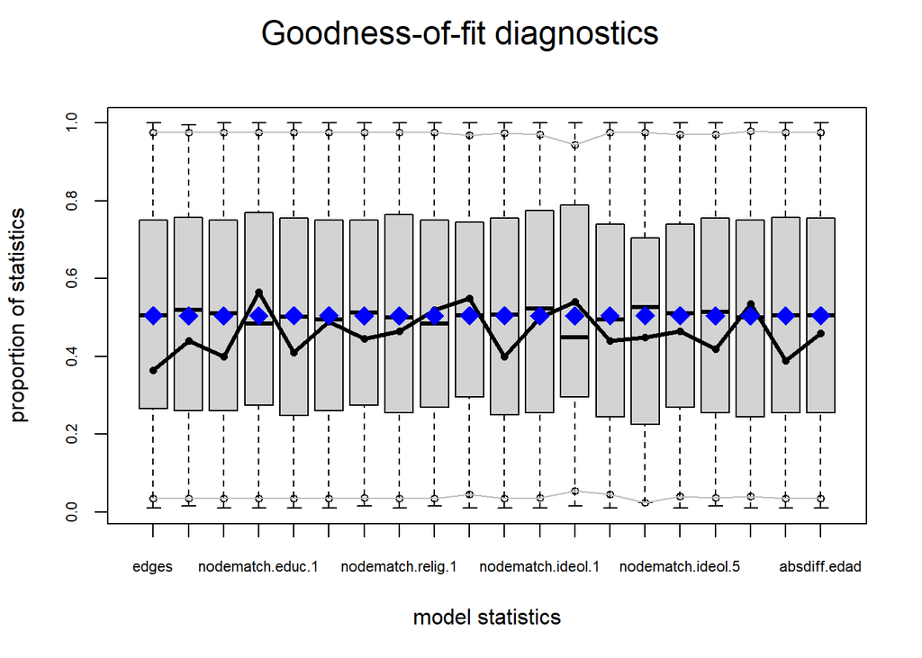

```r
plot(gof(modelo19, GOF="model"))
```

```r
modelo19 <- ergm.ego(elsoc_ego_nofam ~
                  + nodecov("calentorno")
                  + nodecov("machismo")
                  + nodefactor("etnia")
                  + nodefactor("educmpmax")
                  + nodefactor("sexo")
                  + nodefactor("educ")
                  + nodefactor("relig")
                  + nodefactor("ideol")
                  + nodecov("edad")
                  + nodematch("sexo",  diff=TRUE)
                  + nodematch("educ",  diff=TRUE)
                  + nodematch("relig", diff=TRUE)
                  + nodematch("ideol", diff=TRUE)
                  + nodematch("barrio", diff=TRUE)
                  + absdiff("edad"),
                  control=control.ergm.ego(ppopsize="samp",
                                           ppop.wt="sample",
                                           stats.wt="data",
                                           stats.est="survey"),
                  ignore.max.alters=FALSE,
                  boot.R = 10000,
                  ergm = control.ergm(init.method = "MPLE",
                  init.MPLE.samplesize = 5e7,
                  MPLE.constraints.ignore = TRUE,
                  MCMLE.effectiveSize = NULL,
                  MCMC.burnin = 5e4,
                  MCMC.interval = 5e4,
                  MCMC.samplesize = 7500,
                  parallel = 16,
                  SAN.nsteps = 5e7))

summary(modelo19)
```

```
## Call:
## ergm(formula = ergm.formula, constraints = constraints, offset.coef = ergm.offset.coef,
##     target.stats = m, eval.loglik = FALSE, control = control$ergm,
##     ignore.max.alters = FALSE, boot.R = 10000, ergm = ..3)
##
## Monte Carlo Maximum Likelihood Results:
##
##                         Estimate Std. Error MCMC % z value Pr(>|z|)
## offset(netsize.adj)    -7.428927   0.000000      0    -Inf  < 1e-04 ***
## nodecov.calentorno     -0.034679   0.057623      0  -0.602 0.547285
## nodecov.machismo        0.041260   0.083096      0   0.497 0.619520
## nodefactor.etnia.2      0.329973   0.138441      0   2.383 0.017150 *
## nodefactor.educmpmax.2 -0.065843   0.104828      0  -0.628 0.529933
## nodefactor.educmpmax.3  0.106746   0.186471      0   0.572 0.567014
## nodefactor.educmpmax.4  0.107754   0.201697      0   0.534 0.593180
## nodefactor.sexo.2      -1.711455   1.005650      0  -1.702 0.088785 .
## nodefactor.educ.2       0.238457   0.152663      0   1.562 0.118292
## nodefactor.educ.3       0.668314   0.168733      0   3.961  < 1e-04 ***
## nodefactor.educ.4       0.558138   0.185401      0   3.010 0.002609 **
## nodefactor.relig.2     -0.272479   0.159881      0  -1.704 0.088333 .
## nodefactor.relig.3     -0.041602   0.171014      0  -0.243 0.807800
## nodefactor.relig.4     -0.038062   0.178178      0  -0.214 0.830844
## nodefactor.ideol.2      0.096089   0.156978      0   0.612 0.540459
## nodefactor.ideol.3     -0.278124   0.147067      0  -1.891 0.058606 .
## nodefactor.ideol.4     -0.307743   0.154060      0  -1.998 0.045764 *
## nodefactor.ideol.5      0.082934   0.150827      0   0.550 0.582415
## nodefactor.ideol.6     -0.315667   0.163021      0  -1.936 0.052824 .
## nodecov.edad            0.002245   0.002925      0   0.768 0.442669
## nodematch.sexo.1       -0.157605   1.021201      0  -0.154 0.877347
## nodematch.sexo.2        2.960925   1.032833      0   2.867 0.004146 **
## nodematch.educ.1        0.683041   0.240508      0   2.840 0.004511 **
## nodematch.educ.2        0.658496   0.179694      0   3.665 0.000248 ***
## nodematch.educ.3        0.917788   0.204054      0   4.498  < 1e-04 ***
## nodematch.educ.4        1.626120   0.201946      0   8.052  < 1e-04 ***
## nodematch.relig.1       0.723413   0.186459      0   3.880 0.000105 ***
## nodematch.relig.2       1.678935   0.219799      0   7.638  < 1e-04 ***
## nodematch.relig.3       0.249150   0.346854      0   0.718 0.472565
## nodematch.relig.4       1.160157   0.259730      0   4.467  < 1e-04 ***
## nodematch.ideol.1       1.352841   0.300012      0   4.509  < 1e-04 ***
## nodematch.ideol.2       0.218239   0.464561      0   0.470 0.638516
## nodematch.ideol.3      -0.394674   0.238478      0  -1.655 0.097931 .
## nodematch.ideol.4       0.361449   0.296003      0   1.221 0.222048
## nodematch.ideol.5       1.116226   0.230025      0   4.853  < 1e-04 ***
## nodematch.ideol.6       1.312243   0.202557      0   6.478  < 1e-04 ***
## nodematch.barrio.1      0.045188   0.138991      0   0.325 0.745095
## nodematch.barrio.2     -0.079404   0.087616      0  -0.906 0.364792
## absdiff.edad           -0.080792   0.005389      0 -14.993  < 1e-04 ***
## ---
## Signif. codes:  0 '***' 0.001 '**' 0.01 '*' 0.05 '.' 0.1 ' ' 1
##
##
##  The following terms are fixed by offset and are not estimated:
##   offset(netsize.adj)
```

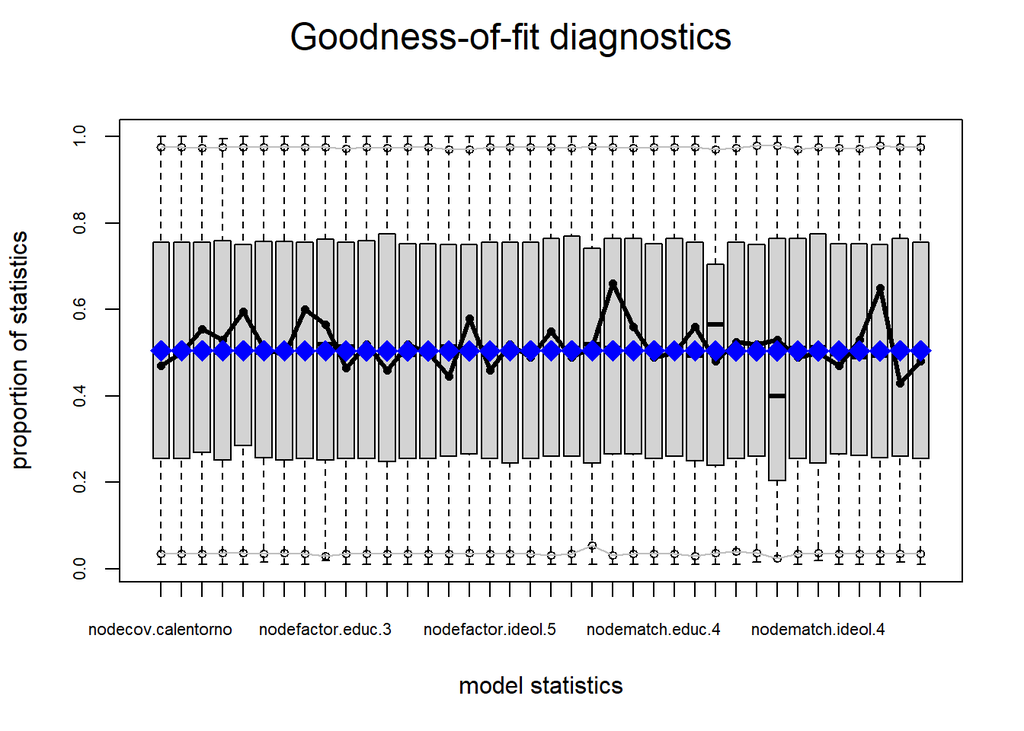

```r
plot(gof(modelo19, GOF="model"))
```

# 20 Extras

## 20.1 Sample para simulación

```r
s1 <- sample(elsoc_ego, 100, replace=TRUE, prob=1:nrow(elsoc_ego$ego))
```

## 20.2 Modelo para graficar

```r
#sim1 <- sample(elsoc_ego, 150, replace = TRUE)
#sim1
#s1[["ego"]]  <-s1[["ego"]]%>%drop_na(relig)
#s1[["alter"]]<-s1[["alter"]]%>%drop_na(relig)
#s1[["ego"]]  <-s1[["ego"]]%>%drop_na(sexo)
#s1[["alter"]]<-s1[["alter"]]%>%drop_na(sexo)
#s1[["ego"]]  <-s1[["ego"]]%>%drop_na(ideol)
#s1[["alter"]]<-s1[["alter"]]%>%drop_na(ideol)
#s1[["ego"]]  <-s1[["ego"]]%>%drop_na(educ)
#s1[["alter"]]<-s1[["alter"]]%>%drop_na(educ)
#s1[["alter"]]<-s1[["alter"]]%>%drop_na(barrio)
#s1[["ego"]]$calentorno<-as.numeric(sim1[["ego"]]$calentorno)
#s1[["ego"]]<-sim1[["ego"]]%>%drop_na(calentorno)
#s1[["ego"]]$machismo<-as.numeric(sim1[["ego"]]$machismo)
#s1[["ego"]]<-sim1[["ego"]]%>%drop_na(machismo)
#elsoc_ego[["ego"]]$educmpmax<-as.numeric(elsoc_ego[["ego"]]$educmpmax)
#sim1[["ego"]]<-sim1[["ego"]]%>%drop_na(educmpmax)
#sim1[["ego"]]<-sim1[["ego"]]%>%drop_na(etnia)

modelo19 <- ergm.ego(s1 ~
                    nodefactor("educ")
                  + nodefactor("ideol")
                  + nodematch("educ")
                  + nodematch("ideol"),
                  ignore.max.alters=FALSE,
                  boot.R = 10000,
                  ergm = control.ergm(init.method = "MPLE",
                  init.MPLE.samplesize = 5e7,
                  MPLE.constraints.ignore = TRUE,
                  MCMLE.effectiveSize = NULL,
                  MCMC.burnin = 5e4,
                  MCMC.interval = 5e4,
                  MCMC.samplesize = 7500,
                  parallel = 16,
                  SAN.nsteps = 5e7))
sim.modelo19 <- simulate(modelo19)
summary(sim.modelo19)
```

```
## Network attributes:
##   vertices = 124
##   directed = FALSE
##   hyper = FALSE
##   loops = FALSE
##   multiple = FALSE
##   bipartite = FALSE
##  total edges = 111
##    missing edges = 0
##    non-missing edges = 111
##  density = 0.01455547
##
## Vertex attributes:
##
##  .ego.ind:
##    integer valued attribute
##    124 values
##
##  .egoID:
##    integer valued attribute
##    124 values
##
##  .sample_weights:
##    numeric valued attribute
##    attribute summary:
##      Min.   1st Qu.    Median      Mean   3rd Qu.      Max.
## 0.0005995 0.0006907 0.0008738 0.0017269 0.0020862 0.0064103
##
##  barrio:
##    character valued attribute
##    attribute summary:
##  1  2
## 29 95
##
##  calentorno:
##    numeric valued attribute
##    attribute summary:
##    Min. 1st Qu.  Median    Mean 3rd Qu.    Max.
##   1.000   3.000   4.000   3.548   4.000   5.000
##
```

[output cut: 151 more lines]

```
##  [97,]   87   88
##  [98,]   88  118
##  [99,]   89   90
## [100,]   90  103
## [101,]   94  100
## [102,]   97  112
## [103,]   98   99
## [104,]  100  123
## [105,]  101  118
## [106,]  102  116
## [107,]  103  124
## [108,]  105  107
## [109,]  112  121
## [110,]  116  119
## [111,]  117  124
```

## 20.3 Educación

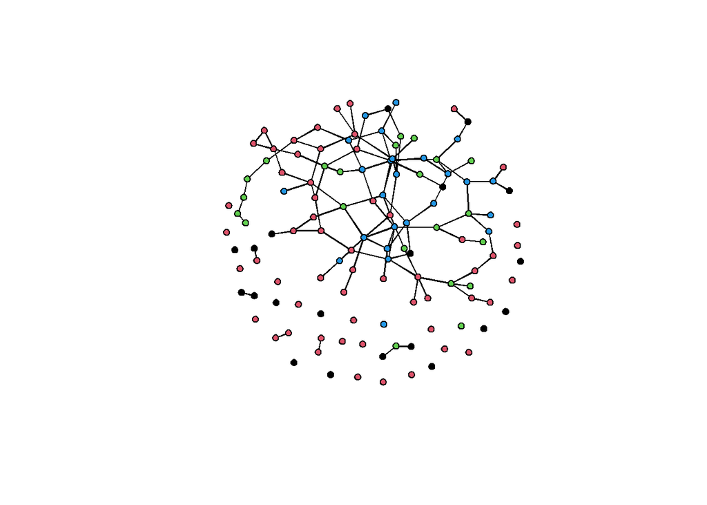

```r
p<-plot(sim.modelo19, vertex.col="educ")
```

```r
#p + legend('bottomleft',fill=1:4,legend=paste('educ',1:4),cex=0.75)
```

## 20.4 Ideología

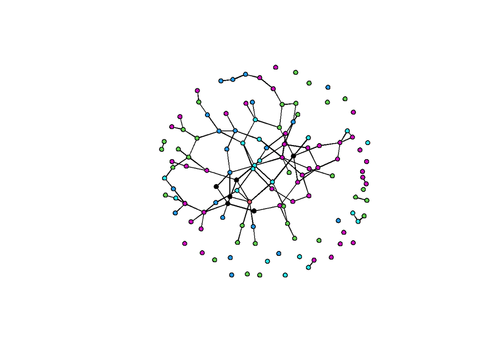

```r
p<-plot(sim.modelo19, vertex.col="ideol")
```

```r
#p + legend('bottomleft',fill=1:6,legend=paste('ideol',1:6),cex=0.75)
```

## 20.5 Religión

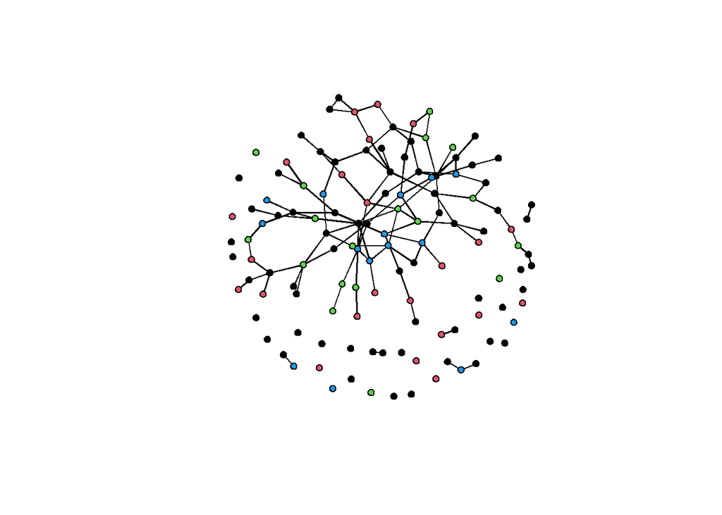

```r
p<-plot(sim.modelo19, vertex.col="relig")
```

```r
#p + legend('bottomleft',fill=1:4,legend=paste('relig',1:4),cex=0.75)
```

# 21 Bibliografía

- Handcock, M. S., & Gile, K. J. (2010). Modeling social networks from sampled data. The Annals of Applied Statistics, 4(1), 5-25. https://doi.org/10.1214/08-AOAS221
- Krivitsky, P. N., & Morris, M. (2017). Inference for social network models from egocentrically sampled data, with application to understanding persistent racial disparities in HIV prevalence in the US. The Annals of Applied Statistics, 11(1), 427-455. https://doi.org/10.1214/16-AOAS1010
- Kuskova, V., & Wasserman, S. (2020). An Introduction to Statistical Models for Networks. The Oxford Handbook of Social Networks, 219.
- Smith, J. A., & Gauthier, G. R. (2020). Estimating Contextual Effects from Ego Network Data. Sociological Methodology, 50(1), 215-275. https://doi.org/10.1177/0081175020922879
- Smith, J. A., McPherson, M., & Smith-Lovin, L. (2014). Social Distance in the United States: Sex, Race, Religion, Age, and Education Homophily among Confidants, 1985 to 2004. American Sociological Review, 79(3), 432-456. https://doi.org/10.1177/0003122414531776
- Smith, J. A. (2012). Macrostructure from Microstructure: Generating Whole Systems from Ego Networks. Sociological Methodology, 42(1), 155-205. https://doi.org/10.1177/0081175012455628